# Math 463 - Lab 3 - Exploratory Data Analysis

Some define statistics as the field that focuses on turning information into knowledge. The first step in that process is to summarize and describe the raw information - the data. In this lab we explore flights, specifically a random sample of 32735 domestic flights that departed from the three major New York City airports in 2013. You will generate simple graphical and numerical summaries of data on these flights and explore delay times. As this is a large data set, along the way you’ll also learn the indispensable skills of data processing and subsetting.

## Getting started

### The data

The [Bureau of Transportation Statistics](https://www.bts.gov/) (BTS) is a statistical agency that is a part of the Research and Innovative Technology Administration (RITA). As its name implies, BTS collects and makes available transportation data, such as the flights data we will be working with in this lab. This particular version of the flights data is contained in the `openintro` package and the dataset is called `nycflights`.

To view the names of the variables, type the command

```r
names(nycflights)
```

This returns the names of the variables in this data frame. The **codebook** (description of the variables) is included below.

- `year`, `month`, `day`: Date of departure
- `dep_time`, `arr_time`: Departure and arrival times, local timezone.
- `dep_delay`, `arr_delay`: Departure and arrival delays, in minutes. Negative times represent early departures/arrivals.
- `carrier`: Two letter carrier abbreviation.
  - `9E`: Endeavor Air Inc.
  - `AA`: American Airlines Inc.
  - `AS`: Alaska Airlines Inc.
  - `B6`: JetBlue Airways
  - `DL`: Delta Air Lines Inc.
  - `EV`: ExpressJet Airlines Inc.
  - `F9`: Frontier Airlines Inc.
  - `FL`: AirTran Airways Corporation
  - `HA`: Hawaiian Airlines Inc.
  - `MQ`: Envoy Air
  - `OO`: SkyWest Airlines Inc.
  - `UA`: United Air Lines Inc.
  - `US`: US Airways Inc.
  - `VX`: Virgin America
  - `WN`: Southwest Airlines Co.
  - `YV`: Mesa Airlines Inc.
- `tailnum`: Plane tail number
- `flight`: Flight number
- `origin`, `dest`: Airport codes for origin and destination. (Google can help you with what code stands for which airport.)
- `air_time`: Amount of time spent in the air, in minutes.
- `distance`: Distance flown, in miles.
- `hour`, `minute`: Time of departure broken in to hour and minutes.

A very useful function for taking a quick peek at your data frame, and viewing its dimensions and data types is `str`, which stands for **str**ucture.

```r
str(nycflights)
```

The `nycflights` data frame is a massive trove of information. Let’s think about some questions we might want to answer with these data:

- We might want to find out how delayed flights headed to a particular destination tend to be.
- We might want to evaluate how departure delays vary over months.
- We might want to determine which of the three major NYC airports has a better on-time percentage for departing flights.

### Seven verbs

The `dplyr` package (which is part of the `tidyverse` package) offers seven verbs (functions) for basic data manipulation:

- `filter()`
- `arrange()`
- `select()`
- `distinct()`
- `mutate()`
- `summarise()`
- `sample_n()`

We will use some of these functions in this lab, and learn about others in a future lab.

## Analysis

### Departure delays in flights to Chicago O’Hare (ORD)

We can examine the distribution of departure delays of all flights with a histogram.

```r
ggplot(data = nycflights) +
  geom_histogram(aes(x = dep_delay)) +
  labs(x = "Departure Delays, in minutes", y = "Count")
```

Histograms are generally a very good way to see the shape of a single distribution of numerical data, but that shape can change depending on how the data is split between the different bins. You can easily define the binwidth you want to use:

```r
ggplot(data = nycflights) +
  geom_histogram(aes(x = dep_delay), binwidth = 15) +
  labs(x = "Departure Delays, in minutes", y = "Count")

ggplot(data = nycflights) +
  geom_histogram(aes(x = dep_delay), binwidth = 150) +
  labs(x = "Departure Delays, in minutes", y = "Count")
```

1. How do these three histograms with the various binwidths compare?

If you want to visualize only on delays of flights headed to Chicago O’Hare, you need to first `filter` the data for flights with that destination (`dest == "ORD"`) and then make a histogram of the departure delays of only those flights.

```r
ord_flights <- nycflights %>%
  filter(dest == "ORD")
ggplot(data = ord_flights, aes(x = dep_delay)) +
  geom_histogram() +
  labs(x = "Departure Delays, in minutes (ORD only)", y = "Count")
```

Let’s decipher these two commands (OK, so it might look like five lines, but the first two physical lines of code are actually part of the same command. It’s common to add a break to a new line after `%>%` to help readability).

- Command 1: Take the `nycflights` data frame, `filter` for flights headed to ORD, and save the result as a new data frame called `ord_flights`.
  - `==` means “if it’s equal to”.
  - `ORD` is in quotation marks since it is a character string.
- Command 2: Basically the same `ggplot` call from earlier for making a histogram, except that it uses the smaller data frame for flights headed to ORD instead of all flights.

**Logical operators:** Filtering for certain observations (e.g. flights from a particular airport) is often of interest in data frames where we might want to examine observations with certain characteristics separately from the rest of the data. To do so we use the `filter` function and a series of **logical operators**. The most commonly used logical operators for data analysis are as follows:

- `==` means “equal to”
- `!=` means “not equal to”
- `>` or `<` means “greater than” or “less than”
- `>=` or `<=` means “greater than or equal to” or “less than or equal to”

You can also obtain numerical summaries for these flights:

```r
ord_flights %>%
  summarise(mean_dd   = mean(dep_delay),
            median_dd = median(dep_delay),
            std_dev_dd = sd(dep_delay),
            IQR_dd = IQR(dep_delay),
            n         = n())
```

**Summary statistics:** Some useful function calls for summary statistics for a single numerical variable are as follows:

- `mean`
- `median`
- `sd`
- `var`
- `IQR`
- `min`
- `max`

Note that each of these functions takes a single vector as an argument and returns a single value.

We can also filter based on multiple criteria. Suppose we are interested in flights headed to San Francisco (SFO) in February:

```r
sfo_feb_flights <- nycflights %>% filter(dest == "SFO", month == 2)
```

Note that we can separate the conditions using commas if we want flights that are both headed to SFO **and** in February. If we are interested in either flights headed to SFO **or** in February we can use the `|` instead of the comma.

1. Create a new data frame that includes flights headed to SFO in February, and save this data frame as `sfo_feb_flights`. How many flights meet these criteria?
2. Describe the distribution of the **arrival** delays of these (SFO in February) flights using a histogram and report appropriate summary.

```r
sfo_feb_flights %>%
  group_by(origin) %>%
  summarise(median_dd = median(dep_delay), iqr_dd = IQR(dep_delay), n_flights = n())
```

Here, we first grouped the data by `origin`, and then calculated the summary statistics.

1. Calculate the median for the arrival delays (`arr_delay`) of flights in in the `sfo_feb_flights` data frame, grouped by carrier. Which carrier is the has the highest median arrival delays?

### Departure delays over months

Which month would you expect to have the highest **average** delay departing from an NYC airport?

Let’s think about how we would answer this question:

- First, calculate monthly averages for departure delays. With the new language we are learning, we need to
  - group by months, then
  - calculate the mean departure delays.
- Then, it will be helpful if we `arrange` these average delays in `desc`ending order.

```r
nycflights %>%
  group_by(month) %>%
  summarize(mean_dd = mean(dep_delay)) %>%
  arrange(desc(mean_dd))
```

1. Which month has the highest average departure delay from an NYC airport? What about the highest median departure delay? Which of these measures (mean and median) is more reliable for deciding which month(s) to avoid flying if you really dislike delayed flights?

We can also visualize the distributions of departure delays across months using side-by-side boxplots:

```r
ggplot(data = nycflights) +
  geom_boxplot(aes(x = factor(month), y = dep_delay)) +
  labs(x = "Month", y = "Departure Delays, in minutes")
```

There is some new syntax here: We want departure delays on the y-axis and the months on the x-axis to produce side-by-side box plots. Side-by-side box plots require a categorical variable on the x-axis, however in the data frame `month` is stored as a numerical variable (numbers 1 - 12). Therefore we can force R to treat this variable as categorical, what R calls a **factor**, variable with `factor(month)`. Also, note that the extreme outliers cause this plot to be difficult to view. Filtering out outliers, with transparency, can be a better way to view the bulk of a dataset with a few very extreme points.

### On-time departure rate for NYC airports

Suppose you will be flying out of NYC and want to know which of the three major NYC airports has the best on-time departure rate of departing flights. Suppose also that for you a flight that is delayed for less than 5 minutes is basically “on-time”. You consider any flight delayed for 5 minutes or more to be “delayed”. This is the most technical part of the lab; read SLOWLY, making sure you understand each sentence and line of code.

In order to determine which airport has the best on-time departure rate, we need to

- first classify each flight as “on-time” or “delayed”,
- then group flights by origin airport,
- then calculate on-time departure rates for each origin airport,
- and finally arrange the airports in descending order for on-time departure percentage.

Let’s start with classifying each flight as “on-time” or “delayed” by creating a new variable with the `mutate` function.

```r
nycflights <- nycflights %>%
  mutate(dep_type = ifelse(dep_delay < 5, "on-time", "delayed"))
```

The first argument in the `mutate` function is the name of the new variable we want to create, in this case `dep_type`. Then if `dep_delay < 5` we classify the flight as `"on-time"` and `"delayed"` if not, i.e. if the flight is delayed for 5 or more minutes.

Note that we are also overwriting the `nycflights` data frame with the new version of this data frame that includes the new `dep_type` variable.

We can handle all the remaining steps in one code chunk:

```r
nycflights %>%
  group_by(origin) %>%
  summarise(ot_dep_rate = sum(dep_type == "on-time") / n()) %>%
  arrange(desc(ot_dep_rate))
```

1. If you were selecting an airport simply based on on-time departure percentage, which NYC airport would you choose to fly out of?

We can also visualize the distribution of on-time departure rates across the three airports using a segmented bar plot (Section 1.7).

```r
ggplot(data = nycflights) +
  geom_bar(aes(x = origin, fill = dep_type)) +
  labs(x = "Origin airport", y = "Count")
```

## More exercises

7. Mutate the data frame so that it includes a new variable that contains the average speed, `avg_speed` traveled by the plane for each flight (in mph). **Hint:** Average speed can be calculated as distance divided by number of hours of travel, and note that `air_time` is given in minutes.
8. What is the tail number of the plane with the fastest `avg_speed`? **Hint:** You can sort by variables in the Data Viewer using the arrows next to the variable names.  
   You can Google this tail number to find out more about the aircraft.
9. Make a scatterplot of `avg_speed` vs. `distance`. Describe the relationship between average speed and distance. **Hint:** Use `geom_point`.
10. Replicate the following plot. **Hint:** The data frame plotted only contains flights from American Airlines, Delta Airlines, and United Airlines, and the points are colored by `carrier`. Once you replicate the plot, determine (roughly) what the cutoff point is for departure delays where you can still expect to get to your destination on-time.

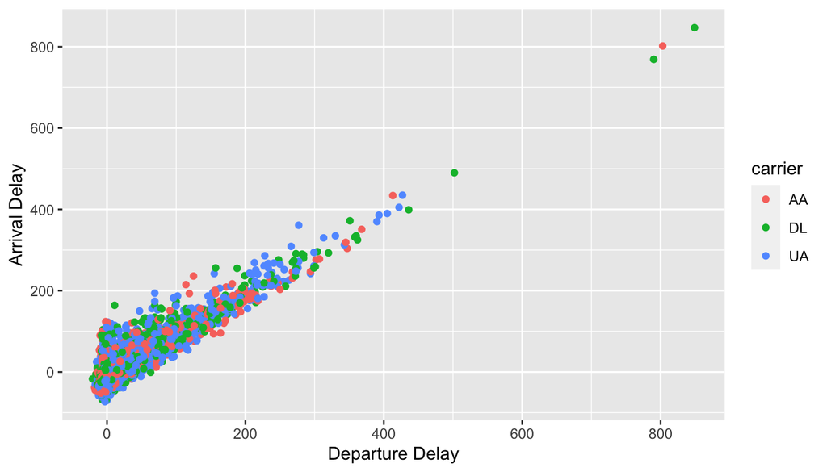

## Turn it in

When you are finished with the lab, you need to upload only your `.html` file to Canvas. **Remember that if you needed output (graphs, numeric output, etc.) to answer a question, the code to generate that output needs to be in the lab report.**